# 1026be4d-8337-4aad-9bb5-fc0060e76cbb

¡Hola!

Mi nombre es Marcos Torres, seré el encargado de revisar tu código el día de hoy.

Cuando vea algo notable o algún asunto en el notebook, te dejaré un comentario o un hint. Se que encontraras la mejor respuesta para resolver todos los comentarios, de no ser así, no te preocupes en futuras iteraciones dejaré comentarios y pistas más específicos.

Este proceso es muy parecido al que se recibe de un gerente o de un Senior Data Scientist en un trabajo real, por lo que te estarás preparando para la experiencia en la vida real.

Encontrarás comentarios en verde, amarillo o rojo como los siguientes:

**Reviewer's comment**

Buen trabajo. ¡Lo hiciste muy bien!

**Reviewer's comment**

Nota. Se puede mejorar.

**Reviewer's comment**

Necesitas corregirlo. Este bloque indica que se requiere una correción. El trabajo no se acepta si tiene estos bloques.

Puedes responder a mis comentarios usando estos bloques:

**Respuesta del estudiante.**

# Análisis de mercado restaruantes en Los Ángeles

La finalidad del siguiente análisis es identificar un partrón que nos permita hacer eficiente la gestión de nuestro café regentado por robots.

**Librerías**

```python
# Importando librerías para nuestro análisis.

import matplotlib.pyplot as plt
import pandas as pd
import plotly.express as px
import plotly.graph_objs as go
import re
from scipy import stats as st
import seaborn as sns
```

**Reviewer's comment**

Bien usaste una celda independiente para importar las librerías.

## Tabla de contenido

- 2 Importando tablas
- 3 Explorando datos
  - 3.1 Corrigiendo datos
- 4 Análisis de datos
  - 4.1 Proporción de tipos de establecimientos
  - 4.2 Proporción cadenas vs no cadenas
  - 4.3 ¿Qué tipo de establecimiento habitualmente es una cadena?
  - 4.4 Características de un restaurante de cadena
  - 4.5 Promedio de asientos por tipo de restaurante
  - 4.6 Calles con más restaurantes
  - 4.7 Calles con 1 solo restaurante
  - 4.8 Distribución de asientos en restaurantes de calles top 10
- 5 Conclusión General

**Reviewer's comment**

Gracias por incluir la tabla de contenidos, le da un toque más profesional y ayuda a navegar más fácilmente por el proyecto.

## Importando tablas

Importaremos una tabla con la información básica de los restaurantes que operan en la ciudad de Los Ángeles.

Regresar

```python
# Importando tablas

rest_data = pd.read_csv('/datasets/rest_data_us.csv')
```

**Reviewer's comment**

Bien, usaste una celda independiente para leer los datos.

## Explorando datos

Verificaremos la distribución de los datos e identificaremos si existen valores nulos o duplicados.

Regresar

```python
# Mostrando información general de los datos.

rest_data.info(memory_usage='deep')
```

```
<class 'pandas.core.frame.DataFrame'>
RangeIndex: 9651 entries, 0 to 9650
Data columns (total 6 columns):
 #   Column       Non-Null Count  Dtype
---  ------       --------------  -----
 0   id           9651 non-null   int64
 1   object_name  9651 non-null   object
 2   address      9651 non-null   object
 3   chain        9648 non-null   object
 4   object_type  9651 non-null   object
 5   number       9651 non-null   int64
dtypes: int64(2), object(4)
memory usage: 2.4 MB
```

```python
# Imprimiendo las primeras 10 filas de la tabla

rest_data.head(20)
```

|  | id | object_name | address | chain | object_type | number |
| --- | --- | --- | --- | --- | --- | --- |
| 0 | 11786 | HABITAT COFFEE SHOP | 3708 N EAGLE ROCK BLVD | False | Cafe | 26 |
| 1 | 11787 | REILLY'S | 100 WORLD WAY 120 | False | Restaurant | 9 |
| 2 | 11788 | STREET CHURROS | 6801 HOLLYWOOD BLVD 253 | False | Fast Food | 20 |
| 3 | 11789 | TRINITI ECHO PARK | 1814 W SUNSET BLVD | False | Restaurant | 22 |
| 4 | 11790 | POLLEN | 2100 ECHO PARK AVE | False | Restaurant | 20 |
| 5 | 11791 | THE SPOT GRILL | 10004 NATIONAL BLVD | False | Restaurant | 14 |
| 6 | 11792 | CPK | 100 WORLD WAY 126 | False | Restaurant | 100 |
| 7 | 11793 | PHO LALA | 3500 W 6TH ST STE 226 | False | Restaurant | 7 |
| 8 | 11794 | ABC DONUTS | 3027 N SAN FERNANDO RD UNIT 103 | True | Fast Food | 1 |
| 9 | 11795 | UPSTAIRS | 3707 N CAHUENGA BLVD | False | Restaurant | 35 |
| 10 | 11796 | EL POLLO LOCO | 5319 W SUNSET BLVD | True | Restaurant | 38 |
| 11 | 11797 | POONG NYUN BAKERY | 928 S WESTERN AVE STE 109 | True | Bakery | 17 |
| 12 | 11798 | EMC RESTAURANT GROUP LLC | 3500 W 6TH ST STE 101 | True | Restaurant | 133 |
| 13 | 11799 | POPULAR DONUTS | 3614 W SLAUSON AVE | False | Fast Food | 18 |
| 14 | 11800 | CUSCATLECA BAKERY | 2501 W SUNSET BLVD #A | True | Bakery | 26 |
| 15 | 11801 | FOOD COURT TRAY WASHING AREA | 928 S WESTERN AVE STE 300 | True | Restaurant | 21 |
| 16 | 11802 | HMS BOUNTY | 3357 WILSHIRE BLVD | False | Restaurant | 147 |
| 17 | 11803 | AN'S CHAN BANG | 244 S OXFORD AVE 5 | False | Restaurant | 10 |
| 18 | 11804 | MURAKAMI | 7160 MELROSE AVE | False | Restaurant | 139 |
| 19 | 11805 | DELTA SKY CLUB T3 | 300 WORLD WAY | False | Restaurant | 103 |

```python
# Imprimiendo las últimas 10 filas de la tabla

rest_data.tail(20)
```

|  | id | object_name | address | chain | object_type | number |
| --- | --- | --- | --- | --- | --- | --- |
| 9631 | 21417 | MEE & GREET | 3500 OVERLAND AVE 150 | False | Restaurant | 2 |
| 9632 | 21418 | PIZZA DE CAL #36 | 252 E MARTIN LUTHER KING JR BLVD | False | Pizza | 9 |
| 9633 | 21419 | COCONUT'S | 809 S HILL ST | False | Restaurant | 44 |
| 9634 | 21420 | MILD SAUCE | 8500 W OLYMPIC BLVD STE B | False | Restaurant | 15 |
| 9635 | 21421 | THE TEA & COFFEE EXCHANGE | 6801 HOLLYWOOD BLVD 120 | False | Cafe | 4 |
| 9636 | 21422 | CHIPOTLE #3094 | 6719 LA TIJERA BLVD A-B | True | Restaurant | 47 |
| 9637 | 21423 | BRAAZO PIZZA | 100 1/2 7TH ST | False | Pizza | 49 |
| 9638 | 21424 | WATTS BURGERS | 10203 S CENTRAL AVE | False | Fast Food | 15 |
| 9639 | 21425 | MCDONALD'S | 1800 S WESTERN AVE | True | Fast Food | 135 |
| 9640 | 21426 | POKE'ME | 1244 WESTWOOD BLVD | False | Restaurant | 5 |
| 9641 | 21427 | OCEAN BASKETS | 2851 CRENSHAW BLVD | False | Restaurant | 15 |
| 9642 | 21428 | TOLOSA | 2635 WHITTIER BLVD | False | Restaurant | 19 |
| 9643 | 21429 | DIVINE DIPS | 601 S LOS ANGELES ST | False | Restaurant | 25 |
| 9644 | 21430 | LA BUFADORA BAR | 3470 E 1ST ST | False | Bar | 24 |
| 9645 | 21431 | SAINT MARC | 10250 SANTA MONICA BLVD 1025 | False | Restaurant | 225 |
| 9646 | 21432 | HALL OF JUSTICE | 217 W TEMPLE AVE | False | Restaurant | 122 |
| 9647 | 21433 | FIN-MELROSE | 5750 MELROSE AVE | False | Restaurant | 93 |
| 9648 | 21434 | JUICY WINGZ | 6741 HOLLYWOOD BLVD | True | Fast Food | 15 |
| 9649 | 21435 | MEDIDATE COFFEE | 548 S SPRING ST STE 100 | False | Cafe | 6 |
| 9650 | 21436 | CAFE SPROUTS | 1300 S SAN PEDRO ST STE 111 | True | Restaurant | 19 |

```python
# Verificando distribución de los datos numéricos

rest_data.describe()
```

|  | id | number |
| --- | --- | --- |
| count | 9651.000000 | 9651.000000 |
| mean | 16611.000000 | 43.695161 |
| std | 2786.148058 | 47.622874 |
| min | 11786.000000 | 1.000000 |
| 25% | 14198.500000 | 14.000000 |
| 50% | 16611.000000 | 27.000000 |
| 75% | 19023.500000 | 46.000000 |
| max | 21436.000000 | 229.000000 |

```python
# Verificando si hay duplicados implícitos en los datos.

rest_data.duplicated().sum()
```

```
0
```

**Reviewer's comment**

Usaste correctamente los métodos de pandas para explorar los datos.

**Conclusión intermedia**

Algunos nombres de restaurantes tienen números en el campo de nombre, también valores nulos en la columna "chain" que especifica si el restaurante pertenece a una cadena. Adicionalmente tenemos restaurantes con solo 1 asiento disponible, debemos verificar a qué corresponde este fenómeno.

Por otra parte, cambiaremos los tipos de datos de las siguientes columnas:

- **chain a bool**: una vez identifiquemos la causa de los valores nulos.
- **object_type a category**: para hacer más eficiente el consumo de memoria.

**Reviewer's comment**

Buenas conclusiones intermedias.

### Corrigiendo datos

Regresar

**object_name**

Crearemos una copia de los datos en la columna de 'object_name', con los nombres de los restaurantes sin números, ni caracteres especiales antes y después del nombre en letras del restaurante.

```python
# Guardando los nombres de los restaurantes sin los números de calle.

rest_data['restaurant_name'] = (rest_data['object_name']
                            .str.replace(r'[^A-z ]+', '', regex=True)
                            .str.strip()
                           )

rest_data['restaurant_name'].head(20)
```

```
0              HABITAT COFFEE SHOP
1                          REILLYS
2                   STREET CHURROS
3                TRINITI ECHO PARK
4                           POLLEN
5                   THE SPOT GRILL
6                              CPK
7                         PHO LALA
8                       ABC DONUTS
9                         UPSTAIRS
10                   EL POLLO LOCO
11               POONG NYUN BAKERY
12        EMC RESTAURANT GROUP LLC
13                  POPULAR DONUTS
14               CUSCATLECA BAKERY
15    FOOD COURT TRAY WASHING AREA
16                      HMS BOUNTY
17                   ANS CHAN BANG
18                        MURAKAMI
19                DELTA SKY CLUB T
Name: restaurant_name, dtype: object
```

**Conclusión**

Nos deshicimos de los números y caracteres especiales antes y después del nombre del restaurante. Sin embargo, los datos tienen varias inconsistencias adicionales respecto a las características del restaurante según el nombre.

**Chain**

```python
# Explorando las filas completas donde la columna es 'NaN'

rest_data[rest_data['chain'].isna()]
```

|  | id | object_name | address | chain | object_type | number | restaurant_name |
| --- | --- | --- | --- | --- | --- | --- | --- |
| 7408 | 19194 | TAQUERIA LOS 3 CARNALES | 5000 E WHITTIER BLVD | NaN | Restaurant | 14 | TAQUERIA LOS CARNALES |
| 7523 | 19309 | JAMMIN JIMMY'S PIZZA | 1641 FIRESTONE BLVD | NaN | Pizza | 1 | JAMMIN JIMMYS PIZZA |
| 8648 | 20434 | THE LEXINGTON THEATER | 129 E 3RD ST | NaN | Restaurant | 35 | THE LEXINGTON THEATER |

```python
# Creando lista con nombres de restaurantes que no se sabe si son o no de cadenas

missing_chain_restaurants = list(rest_data[rest_data['chain'].isna()]['object_name'])

# Mostrando tabla donde los nombres de los restaurantes sin cadena se reflejen para identificar
# si estos pertenecen o no a una cadena

rest_data[rest_data['object_name'].isin(missing_chain_restaurants)]
```

|  | id | object_name | address | chain | object_type | number | restaurant_name |
| --- | --- | --- | --- | --- | --- | --- | --- |
| 7408 | 19194 | TAQUERIA LOS 3 CARNALES | 5000 E WHITTIER BLVD | NaN | Restaurant | 14 | TAQUERIA LOS CARNALES |
| 7523 | 19309 | JAMMIN JIMMY'S PIZZA | 1641 FIRESTONE BLVD | NaN | Pizza | 1 | JAMMIN JIMMYS PIZZA |
| 8648 | 20434 | THE LEXINGTON THEATER | 129 E 3RD ST | NaN | Restaurant | 35 | THE LEXINGTON THEATER |

**Conclusión intermedia**

Considerando que los restaurantes con valores nulos son nombres únicos en nuestra tabla, procederemos a completar sus valores con un "False" para indicar que no pertenecen a una cadena de resturantes.

```python
# Reemplazando NaN's por False

rest_data.fillna(False, inplace=True)

rest_data[rest_data['chain'].isna()]
```

|  | id | object_name | address | chain | object_type | number | restaurant_name |
| --- | --- | --- | --- | --- | --- | --- | --- |

```python
# verificando tipo de datos de la columna 'chain'

rest_data['chain'].dtype
```

```
dtype('bool')
```

**Conclusión**

Los datos nulos de la columna chain fueron sobreescritos de manera apropiada y ahora la columna mantiene un tipo de dato "bool"

**object_type**

```python
# Cambiando tipo de datos de la columna object_type

rest_data['object_type'] = rest_data['object_type'].astype('category')
```

**number**

```python
# Mostrando restuurantes con solo 1 asiento disponible.

rest_data[rest_data['number'] == 1]
```

|  | id | object_name | address | chain | object_type | number | restaurant_name |
| --- | --- | --- | --- | --- | --- | --- | --- |
| 8 | 11794 | ABC DONUTS | 3027 N SAN FERNANDO RD UNIT 103 | True | Fast Food | 1 | ABC DONUTS |
| 35 | 11821 | REGGIE'S DELI & CAFE | 1910 W SUNSET BLVD STE 150 | True | Restaurant | 1 | REGGIES DELI CAFE |
| 93 | 11879 | TACOMIENDO | 11462 GATEWAY BLVD | False | Fast Food | 1 | TACOMIENDO |
| 139 | 11925 | KIKKA SUSHI | 308 WESTWOOD PLZ A233B | True | Restaurant | 1 | KIKKA SUSHI |
| 265 | 12051 | LUCKY STRIKE HOLLYWOOD | 6801 HOLLYWOOD BLVD STE #143 | False | Restaurant | 1 | LUCKY STRIKE HOLLYWOOD |
| ... | ... | ... | ... | ... | ... | ... | ... |
| 9562 | 21348 | 7-ELEVEN STORE #18778D | 7600 W SUNSET BLVD | False | Restaurant | 1 | ELEVEN STORE D |
| 9566 | 21352 | THE BUTLER'S KITCHEN | 5616 E BEVERLY BLVD | False | Restaurant | 1 | THE BUTLERS KITCHEN |
| 9589 | 21375 | WHITE AND BROWN | 603 S MARIPOSA AVE | False | Restaurant | 1 | WHITE AND BROWN |
| 9600 | 21386 | YAKITORI TEN | 3470 W 6TH ST STE 2A | False | Restaurant | 1 | YAKITORI TEN |
| 9610 | 21396 | TERRAZA CAFE COFFEE SHOP | 4017 1/2 CITY TERRACE DR | False | Cafe | 1 | TERRAZA CAFE COFFEE SHOP |

187 rows × 7 columns

**Conclusión intermedia**

Considerando la cantidad de restaurantes con esta característica y que no se refleja algún patrón que identifique el porqué de esta anomalía, proseguiremos con el estudio considerando dichos restaurantes.

**Reviewer's comment**

Buen análisis para estudiar la anomalía.

## Análisis de datos

En esta sección iniciaremos con el análisis de los datos que tenemos para identificar tendencias del negocio.

Regresar

### Proporción de tipo de establecimientos

Identificaremos la proporción de los seis tipos de establecimientos que tenemos en nuestra data y mostraremos cuanto representan en el total de los datos.

Regresar

```python
# Agrupando para identificar la proporción de restaurantes por tipo

rest_type_ratio = (rest_data['object_type']
                   .value_counts(normalize=True)
                   .reset_index()
                   .rename(columns={'index':'object_type',
                                   'object_type':'type_ratio'})
                  )


rest_type_ratio
```

|  | object_type | type_ratio |
| --- | --- | --- |
| 0 | Restaurant | 0.751736 |
| 1 | Fast Food | 0.110455 |
| 2 | Cafe | 0.045073 |
| 3 | Pizza | 0.033157 |
| 4 | Bar | 0.030256 |
| 5 | Bakery | 0.029323 |

```python
# Graficando información resumida

px.bar(rest_type_ratio, x='object_type', y='type_ratio', title='Ratio of restaurants in the city of L.A.',
       color='type_ratio', color_continuous_scale='sunset')
```

[interactive chart not shown]

**Reviewer's comment**

Bien, la gráfica de barras es buena, esta ordenada de mayor a menor y esto facilita su comprensión.

**Conclusión**

De forma dominante los negocios de tipo restaurante dominan ampliamente la escena gastronómica de la ciudad con un 75% de presencia en el mercado. Seguido de los negocios de comida rápida con un 11%, para luego distribuir el 14% restante entre los cafés, pizzerías, bares y panaderías.

### Proporción cadenas vs no cadenas

Trazaremos un gráfico donde se evidencia la diferencia entre los negocios pertenecientes a una cadena y los que no pertenecen.

Regresar

```python
# Agrupando para identificar la cantidad de restaurantes de cadena

rest_chain_ratio = (rest_data['chain']
                    .value_counts(normalize=True)
                    .reset_index()
                    .rename(columns={'chain':'chain_ratio',
                                    'index':'chain'})
                   )

rest_chain_ratio
```

|  | chain | chain_ratio |
| --- | --- | --- |
| 0 | False | 0.619107 |
| 1 | True | 0.380893 |

```python
# Graficando información resumida

px.bar(rest_chain_ratio, x='chain', y='chain_ratio', title='Ratio of restaurants chains in the city of L.A.',
       color='chain_ratio', color_continuous_scale='sunset')
```

[interactive chart not shown]

**Reviewer's comment**

Buena gráfica.

**Conclusión**

De acuerdo a la información mostrada podemos asegurar que casi el 62% de los restaurantes de la ciudad de Los Ángeles no pertenecen a una cadena.

### ¿Qué tipo de establecimiento habitualmente es una cadena?

De acuerdo al tipo de restaurante que existe en la ciudad, determinaremos cuál de ellos es habitualmente una cadena.

Regresar

```python
# Agregando la proporción de cadenas por tipo de restaurante

rest_type_likelihood = (rest_data
                        .groupby('object_type', as_index=False)['chain']
                        .mean()
                        .rename(columns={'chain':'chain_likelihood'})
                        .sort_values(by='chain_likelihood', ascending=False)
                        .reset_index(drop=True)
                       )

# Combinando dataframes para tener la información en una tabla

rest_type_ratio = rest_type_ratio.merge(rest_type_likelihood, on='object_type')

rest_type_ratio
```

|  | object_type | type_ratio | chain_likelihood |
| --- | --- | --- | --- |
| 0 | Restaurant | 0.751736 | 0.315920 |
| 1 | Fast Food | 0.110455 | 0.567542 |
| 2 | Cafe | 0.045073 | 0.611494 |
| 3 | Pizza | 0.033157 | 0.478125 |
| 4 | Bar | 0.030256 | 0.263699 |
| 5 | Bakery | 0.029323 | 1.000000 |

```python
rest_data_clean = rest_data.merge(
    rest_data
    .groupby(['object_type', 'chain'])['id']
    .count()
    .reset_index()
    .rename(columns={'id':'rest_count'}),
    on=['object_type', 'chain'], how='left'
)


rest_data_clean['rest_count'] = rest_data_clean['rest_count']/9651

rest_data_clean
```

|  | id | object_name | address | chain | object_type | number | restaurant_name | rest_count |
| --- | --- | --- | --- | --- | --- | --- | --- | --- |
| 0 | 11786 | HABITAT COFFEE SHOP | 3708 N EAGLE ROCK BLVD | False | Cafe | 26 | HABITAT COFFEE SHOP | 0.017511 |
| 1 | 11787 | REILLY'S | 100 WORLD WAY 120 | False | Restaurant | 9 | REILLYS | 0.514247 |
| 2 | 11788 | STREET CHURROS | 6801 HOLLYWOOD BLVD 253 | False | Fast Food | 20 | STREET CHURROS | 0.047767 |
| 3 | 11789 | TRINITI ECHO PARK | 1814 W SUNSET BLVD | False | Restaurant | 22 | TRINITI ECHO PARK | 0.514247 |
| 4 | 11790 | POLLEN | 2100 ECHO PARK AVE | False | Restaurant | 20 | POLLEN | 0.514247 |
| ... | ... | ... | ... | ... | ... | ... | ... | ... |
| 9646 | 21432 | HALL OF JUSTICE | 217 W TEMPLE AVE | False | Restaurant | 122 | HALL OF JUSTICE | 0.514247 |
| 9647 | 21433 | FIN-MELROSE | 5750 MELROSE AVE | False | Restaurant | 93 | FINMELROSE | 0.514247 |
| 9648 | 21434 | JUICY WINGZ | 6741 HOLLYWOOD BLVD | True | Fast Food | 15 | JUICY WINGZ | 0.062688 |
| 9649 | 21435 | MEDIDATE COFFEE | 548 S SPRING ST STE 100 | False | Cafe | 6 | MEDIDATE COFFEE | 0.017511 |
| 9650 | 21436 | CAFE SPROUTS | 1300 S SAN PEDRO ST STE 111 | True | Restaurant | 19 | CAFE SPROUTS | 0.237488 |

9651 rows × 8 columns

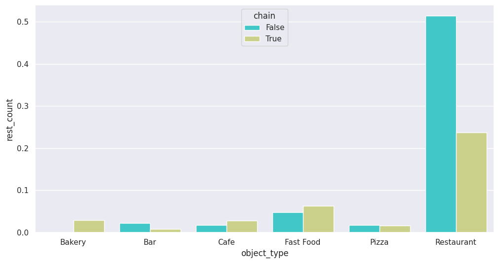

```python
# Gráfico con seaborn

plt.figure(figsize=(12,6))
sns.set(style="darkgrid")
sns.barplot(data=rest_data_clean, x='object_type', y='rest_count',
            hue='chain', palette='rainbow')
plt.show()
```

```python
# Graficando información resumida

px.bar(rest_type_ratio.sort_values(by='chain_likelihood', ascending=False),
       x='object_type', y='chain_likelihood',
       title='Ratio of restaurants type being a chain in the city of L.A.',
       color='chain_likelihood', color_continuous_scale='sunset')
```

[interactive chart not shown]

**Reviewer's comment**

Bien. Ya haz realizado varias gráficas de este estilo, podrías crear una función que solo reciba el data frame y las columnas a graficar.

**Conclusión**

Los restaurantes que siempre son de cadena serían las panaderías, seguido de los cafés y comida rápida donde más de la mitad de las oportunidades son de cadena.

### Características de un restaurante de cadena

Mostraremos el comportamiento respecto a la cantidad de restaurantes y el número de asientos disponibles.

Regresar

```python
# Filtrando la tabla completa por restaurantes solo de cadena, y que tengan más de 3 restaurantes por cadena

chain_rest_data = (rest_data[rest_data['chain'] == True]
                   .groupby('restaurant_name')
                   .agg({'restaurant_name':'count',
                        'number':'mean'})
                   .rename(columns={'restaurant_name':'rest_count',
                                   'number':'seat_mean'})
                   .reset_index()
                   .sort_values(by='rest_count', ascending=False)
                   .query('rest_count > 3')
                  )

chain_rest_data.head(15)
```

|  | restaurant_name | rest_count | seat_mean |
| --- | --- | --- | --- |
| 1711 | SUBWAY | 122 | 17.081967 |
| 1697 | STARBUCKS COFFEE | 87 | 24.850575 |
| 1162 | MCDONALDS | 82 | 93.085366 |
| 782 | JACK IN THE BOX | 52 | 64.980769 |
| 1819 | THE COFFEE BEAN TEA LEAF | 51 | 26.235294 |
| 185 | BURGER KING | 38 | 84.789474 |
| 511 | EL POLLO LOCO | 36 | 67.833333 |
| 416 | DOMINOS PIZZA | 33 | 13.696970 |
| 1692 | STARBUCKS | 32 | 33.625000 |
| 1752 | TACO BELL | 30 | 48.533333 |
| 1435 | PIZZA HUT | 30 | 14.633333 |
| 2024 | YOSHINOYA | 28 | 46.857143 |
| 233 | CARLS JR | 23 | 93.869565 |
| 1362 | PANDA EXPRESS | 23 | 36.043478 |
| 787 | JAMBA JUICE | 19 | 19.473684 |

**Reviewer's comment**

Muy buen uso de los métodos y usaste bien las sangrías junto con la estructura de los métodos.

```python
# Graficando scatter plot para ver la relación entre el número de restaurantes y los asientos disponibles.

px.scatter(chain_rest_data, x='rest_count', y='seat_mean', color='seat_mean',
          color_continuous_scale='sunset', trendline='lowess',
           title='Seats average of a more than 3 restaurants chain'
          )
```

[interactive chart not shown]

**Conclusión**

La tendencia va en ascenso para las cadenas con 50 o menos restaurantes, donde a mayor cantidad de restaurantes, mayor la cantidad promedio de asientos. Sin embargo, luego que una cadena sobrepasa los 50 establecimientos desciende la cantidad promedio de asientos dentro de un restaurante.

**Reviewer's comment**

Bien, la gráfica muestra bien el promedio de asientos. Como consejo estás usando un estilo de gráfica que puede tener 3 valores (eje X, eje Y y el color) podrías usar ese color para mostrar otra variable en lugar de repetir la variable seat_mean.

### Promedio de asientos por tipo de restaurantes

Mostraremos cuantos asientos tienen en promedio los diferentes tipos de establecimientos que tenemos en la data.

Regresar

```python
# Agregando el promedio de asientos por tipo de restaurantes

rest_type_seat_mean = (rest_data
                        .groupby('object_type', as_index=False)['number']
                        .mean().round()
                        .rename(columns={'number':'seat_mean'})
                        .sort_values(by='seat_mean', ascending=False)
                        .reset_index(drop=True)
                       )

# Combinando dataframes para tener la información en una tabla

rest_type_ratio = rest_type_ratio.merge(rest_type_seat_mean, on='object_type')

rest_type_ratio
```

|  | object_type | type_ratio | chain_likelihood | seat_mean |
| --- | --- | --- | --- | --- |
| 0 | Restaurant | 0.751736 | 0.315920 | 48.0 |
| 1 | Fast Food | 0.110455 | 0.567542 | 32.0 |
| 2 | Cafe | 0.045073 | 0.611494 | 25.0 |
| 3 | Pizza | 0.033157 | 0.478125 | 28.0 |
| 4 | Bar | 0.030256 | 0.263699 | 45.0 |
| 5 | Bakery | 0.029323 | 1.000000 | 22.0 |

```python
# Graficando información resumida

px.bar(rest_type_ratio.sort_values(by='seat_mean', ascending=False),
       x='object_type', y='seat_mean',
       title='Average seats by restaurant type',
       color='seat_mean', color_continuous_scale='sunset')
```

[interactive chart not shown]

**Reviewer's comment**

Muy bien, los nombres de los ejes podría ser cambiado para que no sea el mismo que el nombre de la columna. Por ejemplo cambiar seat_mean por promedio de asientos y object_type por Tipo de local.

**Conclusión**

En promedio los restaurantes son los establecimientos con mayor cantidad para atender comensales. Sin embargo no podemos establecer la eficacia para generar ingresos de este tipo de locales ya que no contamos con ingresos en nuestra data de estudio.

### Calles con más restaurantes

Reflejaremos cuáles son las calles de la ciudad con más presencia en negocios de comida.

Regresar

```python
# Extrayendo los nombres de la calle de la columna de dirección.

rest_data['street_name'] = (rest_data['address']
                            # Eliminando los números antes del nombre de la calle
                            .str.replace('^\d+\s','', regex=True)
                            # Eliminando El
                            .str.replace('(^N |^W |^E |^S |#)','', regex=True)
                            .str.replace('\d+$','', regex=True)
                            .str.replace('(STE [A-z]$|STE $|LVL|STE \d+[A-z]$)','', regex=True)
                           ).str.strip()


rest_data['street_name'].head(25)
```

```
0          EAGLE ROCK BLVD
1                WORLD WAY
2           HOLLYWOOD BLVD
3              SUNSET BLVD
4            ECHO PARK AVE
5            NATIONAL BLVD
6                WORLD WAY
7                   6TH ST
8     SAN FERNANDO RD UNIT
9            CAHUENGA BLVD
10             SUNSET BLVD
11             WESTERN AVE
12                  6TH ST
13             SLAUSON AVE
14           SUNSET BLVD A
15             WESTERN AVE
16           WILSHIRE BLVD
17              OXFORD AVE
18             MELROSE AVE
19               WORLD WAY
20                  6TH ST
21                  6TH ST
22           WILSHIRE BLVD
23                 WALL ST
24             MELROSE AVE
Name: street_name, dtype: object
```

```python
# Agrupando por nombre de calle para calcular la cantidad de restaurantes.

street_name_group = (rest_data
                     .groupby('street_name', as_index=False)
                     .agg({'id':'count'})
                     .rename(columns={'id':'rest_count',})
                     .sort_values(by='rest_count', ascending=False)
                     .reset_index(drop=True)
                    )

# Guardando una lista con las 10 calles con más resturantes
top_10_streets = list(street_name_group['street_name'][0:10])

# Agrupando para establecer la cantidad de typos de restaurante en las mejores 10 calles
street_name_group_by_type = (rest_data[rest_data['street_name']
                                       .isin(top_10_streets)]
                             .groupby(['street_name', 'object_type'])['id']
                             .count()
                             .sort_values(ascending=False)
                             .reset_index()
                             .rename(columns={'id':'type_count'})
                            )

# Uniendo tablas

street_name_group_by_type = street_name_group.merge(street_name_group_by_type, on='street_name')

street_name_group_by_type.head(10)
```

|  | street_name | rest_count | object_type | type_count |
| --- | --- | --- | --- | --- |
| 0 | SUNSET BLVD | 369 | Restaurant | 269 |
| 1 | SUNSET BLVD | 369 | Fast Food | 31 |
| 2 | SUNSET BLVD | 369 | Cafe | 27 |
| 3 | SUNSET BLVD | 369 | Pizza | 16 |
| 4 | SUNSET BLVD | 369 | Bar | 14 |
| 5 | SUNSET BLVD | 369 | Bakery | 12 |
| 6 | PICO BLVD | 356 | Restaurant | 272 |
| 7 | PICO BLVD | 356 | Fast Food | 30 |
| 8 | PICO BLVD | 356 | Pizza | 16 |
| 9 | PICO BLVD | 356 | Bakery | 13 |

```python
# Graficando por cantidad de restaurantes por calle

px.bar(street_name_group[0:10], x='street_name', y='rest_count',
       title='Top 10 streets with most restaurants', color='rest_count',
       color_continuous_scale = 'sunset'
      )
```

[interactive chart not shown]

**Reviewer's comment**

Bien, ¡La gráfica se ve muy bien!

```python
# Graficando por tipo de restaurantes

px.bar(street_name_group_by_type, x='street_name', y='type_count',
       title='Top 10 streets with most restaurants by type',
       color='object_type', color_discrete_sequence=px.colors.qualitative.Bold,
      labels={'type_count':'restaurants_count'})
```

[interactive chart not shown]

**Reviewer's comment**

Buen uso del stack de las gráficas de barras.

**Conclusión**

La calle con más establecimientos de comida es la "Sunset Boulevard", tiene en su mayoría restaurantes, sin embargo, lidera es en cafés, pizzerías y bares.

En el caso de la "Wilshire Boulevard" es la calle con más restaurantes. Por último, la calle con más establecimientos de comida rápida sería la "Figueroa Street".

### Calles con un solo restaurante

Mostraremos la cantidad de calles que tienen solo un restaurante.

Regresar

```python
# Calculando la cantidad de calles con solo 1 restaurante

len(street_name_group[street_name_group['rest_count']== 1].index)
```

```
787
```

### Distribución de asientos en restaurantes de calles top 10

Observaremos como se distribuyen los restaurantes y sus asientos disponibles para las calles con más restaurantes.

Regresar

```python
# Agrupando para mostrar la cantidad promedio de asientos en los restaurantes ubicados en nuestras top 10 calles.

seats_in_top_10_street_rest = (rest_data[rest_data['street_name'].isin(top_10_streets)]
                               .groupby('street_name', as_index=False)['number']
                               .mean().round()
                               .sort_values(by='number', ascending=False)
                               .reset_index(drop=True)
                              )

seats_in_top_10_street_rest
```

|  | street_name | number |
| --- | --- | --- |
| 0 | HOLLYWOOD BLVD | 54.0 |
| 1 | WILSHIRE BLVD | 54.0 |
| 2 | SUNSET BLVD | 49.0 |
| 3 | OLYMPIC BLVD | 48.0 |
| 4 | VERMONT AVE | 45.0 |
| 5 | FIGUEROA ST | 44.0 |
| 6 | WESTERN AVE | 42.0 |
| 7 | 3RD ST | 41.0 |
| 8 | PICO BLVD | 41.0 |
| 9 | SANTA MONICA BLVD | 36.0 |

```python
# Graficando por cantidad de restaurantes por calle

px.bar(seats_in_top_10_street_rest, x='street_name', y='number',
       title='Top 10 streets seats distribution', color='number',
       color_continuous_scale = 'sunset', labels={'number':'seat_average'}
      )
```

[interactive chart not shown]

```python
# Graficando histograma para distribución de asientos en las top 10 calles

px.histogram(rest_data[rest_data['street_name'].isin(top_10_streets)], x='number',
             title='Distribution of seats in top 10 streets', labels={'number': 'seats available'}
            )
```

[interactive chart not shown]

**Conclusión**

Las calles Hollywood Boulevard y Wilshire Boulevard promedian un total de 54 asientos por restaurante, cinco más que nuestra calle con más restaurantes la Sunset Boulevard.

Por otra parte podemos ver que la mayoría de los restaurantes tienen hasta 50 asientos disponibles en nuestras 10 calles con mas establecimientos de comida.

## Conclusión General

Iniciamos realizando varias correcciones a nuestros datos, comenzando por la búsqueda y reemplazo de valores nulos, adicionalmente usamos expresiones regulares para corregir la mayor cantidad de datos posibles en la columna del nombre del restaurante.

Al iniciar nuestro análisis, procedimos a mostrar diferentes proporciones de como se comportan los tipos de establecimientos así como el comportamiento de los establecimientos de cadenas. Adicionalmente, observamos la distribución entre la cantidad de asientos disponibles en una cadena de restaurantes contra la cantidad de restaurantes que tienen disponibles.

Continuando, determinamos cuáles son las 10 calles con más presencia de establecimientos de comida y observamos como se distribuyen la cantidad de asientos disponibles en los establecimientos las mencionadas calles.

En conclusión, podemos sugerir, dependiendo de los costos del establecimiento, que se tomen una de las 10 calles con más presencia de establecimentos de comida, considerando que la demanda en dichas calles es lo suficientemente grande para asegurar la rentabilidad del negocio.

Adjunto presentación con conclusiones de la investigación: [link](https://drive.google.com/file/d/1feONJ59po_Jxhp5HnNXy9e4uQw4qy_XD/view?usp=sharing)

Regresar

**Reviewer's comment**

Buenas conclusiones. Basadas en lo observado a lo largo del proyecto.

**Reviewer's comment**

La presentación es buena y tiene un buen manejo de las proporciones de texto e imágenes. El único comentario es cambiar el color de las letras para que sea más fácil de leer.

**Reviewer's comment**

¡Hola!

Te quiero felicitar por tu proyecto está bastante completo. Se nota la dedicación para realizarlo. Deje algunos comentarios opcionales en bloques de color amarillo, pero no es necesario realizarlos para que pueda aprobar tu proyecto.

Puedo aprobar tu proyecto, felicidades y éxito en los próximos sprints.

Saludos, Marcos.